# 09 Dollar threshold model

# Goal

Explore whether using a $\text{giving} \geq g$ dollar threshold improves donor identification compared to no threshold, i.e.

$$E \left( \text{giving, g level donor | covariates} \right) = E \left(\text{giving | g level donor, covariates} \right) P \left(\text{g level donor | covariates} \right)$$

# Setup

```r
library(tidyverse)
library(reshape2)
library(gridExtra)
library(splines)
library(lubridate)
library(wranglR)
library(Boruta)
library(foreach)
library(doParallel)
library(glmnet)
library(glmnetUtils)
library(mgcv)
# Functions adapted from previous analysis steps
source('code/functions.R')
# Visualization functions adapted fron previous analysis steps
source('code/functions_viz.R')
# Set number of available CPU cores
registerDoParallel(detectCores() - 2)
```

```r
# Parameters
train_fy <- 2016
filepath <- 'data/2018-11-30 point-in-time data.xlsx'
sheetname <- 'Select point_in_time_model'
# Import data
source('code/generate-pit-data.R')
# Run data generation functions
giving.threshold = 1E4
modeling.data <- generate_pit_data(filepath, sheetname) %>%
  generate_additional_predictors(giving.threshold = giving.threshold)
```

```
 27249 failed to parse.
```

```r
# Withhold 10% of data as test set
xv <- KFoldXVal(modeling.data, k = 2, prop = .1, seed = 6988432)
holdoutdat <- modeling.data[xv[[1]], ]
traindat <- modeling.data[xv[[2]], ]
remove(xv)
```

Setting $g =$ $10,000 yields 377 donors.

# Classification model

## Variable selection

```r
# Include all donors
samp <- modeling.data %>% filter(rv.gave == TRUE)
# Sample rows of nondonors
prop = 1/20 # Proportion of nondonors to sample
set.seed(378055)
samp <- rbind(
  samp
  , sample_n(modeling.data %>% filter(rv.gave == FALSE)
             , size = nrow(modeling.data %>% filter(rv.gave == FALSE)) * prop)
)
# Run Boruta algorithm
rf.vars <- Boruta(
  y = as.numeric(samp$rv.gave)
  , x = samp %>% select(-rv.amt, -rv.gave, -ID_NUMBER, -HOUSEHOLD_ID, -INSTITUTIONAL_SUFFIX, -DEGREES_CONCAT)
  , seed = 8906
)
```

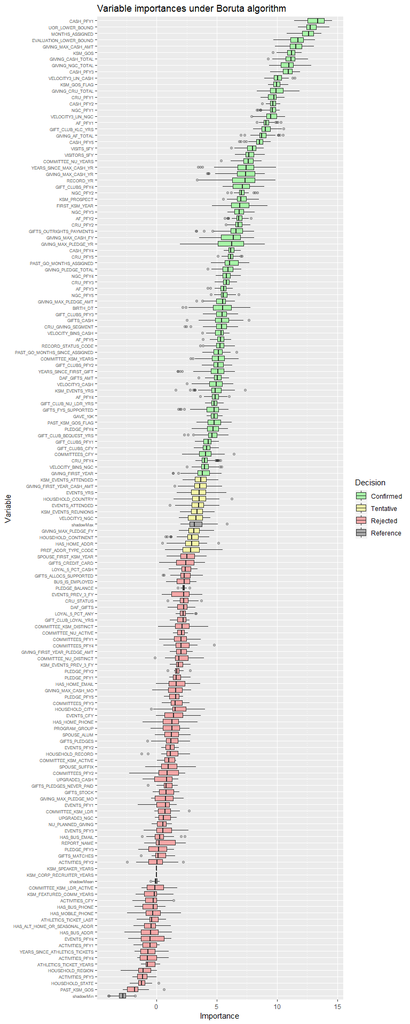

```r
rf.vars %>% Borutadata() %>% Borutaplotter()
```

```r
glm.recommended.vars <- rf.vars %>% TentativeRoughFix()
print(glm.recommended.vars)
```

```
Boruta performed 99 iterations in 4.782104 mins.
Tentatives roughfixed over the last 99 iterations.
 74 attributes confirmed important: AF_PFY1, AF_PFY2, AF_PFY3, AF_PFY4,
AF_PFY5 and 69 more;
 77 attributes confirmed unimportant: ACTIVITIES_CFY, ACTIVITIES_PFY1,
ACTIVITIES_PFY2, ACTIVITIES_PFY3, ACTIVITIES_PFY4 and 72 more;
```

## Model tuning

```r
gam_p <- gam(
  rv.gave ~
    s(CASH_PFY1) +
    s(CASH_PFY2) +
    s(CASH_PFY3) +
    s(CASH_PFY4) +
    s(CASH_PFY5) +
    s(NGC_PFY1) +
    s(NGC_PFY2) +
    s(NGC_PFY3) +
    s(NGC_PFY4) +
    s(NGC_PFY5) +
    s(VELOCITY3_LIN_CASH) +
    CRU_GIVING_SEGMENT +
    s(GIFTS_OUTRIGHTS_PAYMENTS) +
    s(GIVING_MAX_CASH_AMT) +
    s(GIVING_MAX_PLEDGE_AMT) +
    s(GIVING_CASH_TOTAL) +
    s(GIFTS_FYS_SUPPORTED) +
    s(VISITS_5FY) +
    s(COMMITTEE_NU_YEARS) +
    s(GIVING_MAX_CASH_YR) +
    s(RECORD_YR) +
    KSM_PROSPECT +
    s(UOR_LOWER_BOUND) +
    s(MONTHS_ASSIGNED) +
    s(KSM_EVENTS_YRS) +
    s(COMMITTEES_CFY) +
    BUS_IS_EMPLOYED
  , data = traindat
  , family = 'binomial'
  , control = list(nthreads = 10)
)
```

```r
summary(gam_p)
```

```
Family: binomial
Link function: logit

Formula:
rv.gave ~ s(CASH_PFY1) + s(CASH_PFY2) + s(CASH_PFY3) + s(CASH_PFY4) +
    s(CASH_PFY5) + s(NGC_PFY1) + s(NGC_PFY2) + s(NGC_PFY3) +
    s(NGC_PFY4) + s(NGC_PFY5) + s(VELOCITY3_LIN_CASH) + CRU_GIVING_SEGMENT +
    s(GIFTS_OUTRIGHTS_PAYMENTS) + s(GIVING_MAX_CASH_AMT) + s(GIVING_MAX_PLEDGE_AMT) +
    s(GIVING_CASH_TOTAL) + s(GIFTS_FYS_SUPPORTED) + s(VISITS_5FY) +
    s(COMMITTEE_NU_YEARS) + s(GIVING_MAX_CASH_YR) + s(RECORD_YR) +
    KSM_PROSPECT + s(UOR_LOWER_BOUND) + s(MONTHS_ASSIGNED) +
    s(KSM_EVENTS_YRS) + s(COMMITTEES_CFY) + BUS_IS_EMPLOYED

Parametric coefficients:
                               Estimate Std. Error z value Pr(>|z|)
(Intercept)                     -6.4350     1.0346  -6.220 4.98e-10 ***
CRU_GIVING_SEGMENTDonor         -3.0025     2.1499  -1.397   0.1625
CRU_GIVING_SEGMENTLapsed        -2.8718     2.1084  -1.362   0.1732
CRU_GIVING_SEGMENTLoyal 2 of 3  -2.7820     2.1378  -1.301   0.1931
CRU_GIVING_SEGMENTLoyal 3+      -2.8336     2.1509  -1.317   0.1877
CRU_GIVING_SEGMENTLYBUNT        -3.1228     2.1655  -1.442   0.1493
CRU_GIVING_SEGMENTNon           -3.7649     2.1487  -1.752   0.0798 .
CRU_GIVING_SEGMENTPYBUNT        -3.3939     2.1296  -1.594   0.1110
KSM_PROSPECTNo                  -0.5455     0.2491  -2.190   0.0286 *
KSM_PROSPECTPast                -0.6792     0.4090  -1.661   0.0968 .
BUS_IS_EMPLOYEDTRUE              0.5584     0.2575   2.168   0.0301 *
---
Signif. codes:  0 ‘***’ 0.001 ‘**’ 0.01 ‘*’ 0.05 ‘.’ 0.1 ‘ ’ 1

Approximate significance of smooth terms:
                              edf Ref.df Chi.sq  p-value
s(CASH_PFY1)                6.497  7.378 11.100  0.11890
s(CASH_PFY2)                2.548  3.164  9.928  0.02056 *
s(CASH_PFY3)                1.530  1.875 10.206  0.00380 **
s(CASH_PFY4)                1.001  1.001  1.322  0.25059
s(CASH_PFY5)                1.000  1.000  4.699  0.03021 *
s(NGC_PFY1)                 4.178  5.029 10.402  0.06651 .
s(NGC_PFY2)                 1.003  1.005  5.982  0.01482 *
s(NGC_PFY3)                 1.003  1.006  8.372  0.00389 **
s(NGC_PFY4)                 1.003  1.006  4.145  0.04253 *
s(NGC_PFY5)                 5.727  6.715 14.759  0.04257 *
s(VELOCITY3_LIN_CASH)       7.568  8.403 19.546  0.01597 *
s(GIFTS_OUTRIGHTS_PAYMENTS) 1.002  1.004  1.034  0.30865
s(GIVING_MAX_CASH_AMT)      2.913  3.741  6.346  0.10041
s(GIVING_MAX_PLEDGE_AMT)    1.004  1.008  1.348  0.24786
s(GIVING_CASH_TOTAL)        2.059  2.669  1.197  0.58654
s(GIFTS_FYS_SUPPORTED)      1.003  1.005  0.492  0.48606
s(VISITS_5FY)               5.413  6.258 16.825  0.01165 *
s(COMMITTEE_NU_YEARS)       1.002  1.005  8.268  0.00407 **
s(GIVING_MAX_CASH_YR)       1.003  1.007  5.854  0.01586 *
s(RECORD_YR)                1.006  1.012  0.846  0.36365
s(UOR_LOWER_BOUND)          2.420  2.914 29.977 2.83e-06 ***
s(MONTHS_ASSIGNED)          1.002  1.004  1.181  0.27844
s(KSM_EVENTS_YRS)           5.572  6.572 15.707  0.02014 *
s(COMMITTEES_CFY)           1.003  1.007  0.402  0.52729
---
Signif. codes:  0 ‘***’ 0.001 ‘**’ 0.01 ‘*’ 0.05 ‘.’ 0.1 ‘ ’ 1

R-sq.(adj) =  0.361   Deviance explained =   58%
UBRE = -0.97429  Scale est. = 1         n = 76096
```

```r
theta1 <- sum(traindat$rv.gave) / nrow(traindat)
gam_stats <- conf_matrix(gam_p, newdata = holdoutdat, rv = 'rv.gave', threshold = theta1)
gam_stats5 <- conf_matrix(gam_p, newdata = holdoutdat, rv = 'rv.gave', threshold = 0.5)
```

```r
data.frame(
  model = c('gam', 'gam .5')
  , error = c(gam_stats$error, gam_stats5$error)
  , precision = c(gam_stats$precision, gam_stats5$precision)
  , sensitivity = c(gam_stats$sensitivity, gam_stats5$sensitivity)
  , F1 = c(gam_stats$F1_score, gam_stats5$F1_score)
)
```

| model | error | precision | sensitivity | F1 |
| --- | --- | --- | --- | --- |
| gam | 0.055581835 | 0.07509881 | 0.950 | 0.1391941 |
| gam .5 | 0.003547777 | 0.70833333 | 0.425 | 0.5312500 |

Of course, using threshold $\hat{\theta} =$ 0.0044 results in much higher sensitivity at the cost of false positives.

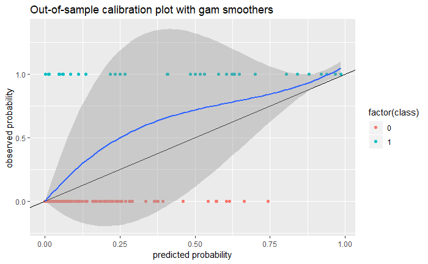

```r
data.frame(
  class = as.numeric(holdoutdat$rv.gave)
  , prediction = predict(gam_p, newdata = holdoutdat, type = 'response')
) %>%
  ggplot(aes(x = prediction, y = class)) +
  geom_point(aes(color = factor(class))) +
  geom_abline(slope = 1, intercept = 0) +
  geom_smooth(method = 'loess') +
  labs(title = 'Out-of-sample calibration plot with gam smoothers'
       , x = 'predicted probability'
       , y = 'observed probability')
```

The out-of-sample calibration looks so-so.

# Regression model

## Variable selection

```r
mg.donors <- traindat %>%
  filter(rv.gave == TRUE) %>%
  select(-rv.gave, -ID_NUMBER, -HOUSEHOLD_ID, -INSTITUTIONAL_SUFFIX, -DEGREES_CONCAT)
# Run Boruta algorithm
rf.vars.lm <- Boruta(
    y = log10(mg.donors$rv.amt)
    , x = mg.donors %>% select(-rv.amt)
    , seed = 3137965
  )
```

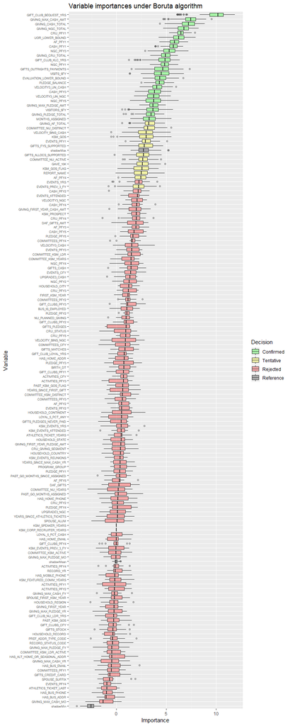

```r
rf.vars.lm %>% Borutadata() %>% Borutaplotter()
```

```r
lm.recommended.vars <- rf.vars.lm %>% TentativeRoughFix()
print(lm.recommended.vars)
```

```
Boruta performed 99 iterations in 17.26885 secs.
Tentatives roughfixed over the last 99 iterations.
 26 attributes confirmed important: AF_PFY1, AF_PFY4, CASH_PFY1, CASH_PFY3,
CRU_PFY1 and 21 more;
 125 attributes confirmed unimportant: ACTIVITIES_CFY, ACTIVITIES_PFY1,
ACTIVITIES_PFY2, ACTIVITIES_PFY3, ACTIVITIES_PFY4 and 120 more;
```

```r
lm.recommended.vars$finalDecision[which(lm.recommended.vars$finalDecision == 'Confirmed')] %>% names()
```

```
 [1] "GIVING_MAX_CASH_AMT"      "GIVING_MAX_PLEDGE_AMT"    "GIVING_CASH_TOTAL"
 [4] "GIVING_PLEDGE_TOTAL"      "GIVING_NGC_TOTAL"         "GIVING_CRU_TOTAL"
 [7] "GIFTS_ALLOCS_SUPPORTED"   "GIFTS_OUTRIGHTS_PAYMENTS" "PLEDGE_BALANCE"
[10] "CASH_PFY1"                "CASH_PFY3"                "NGC_PFY1"
[13] "NGC_PFY3"                 "NGC_PFY5"                 "AF_PFY1"
[16] "AF_PFY4"                  "CRU_PFY1"                 "GIFT_CLUB_KLC_YRS"
[19] "GIFT_CLUB_BEQUEST_YRS"    "EVALUATION_LOWER_BOUND"   "UOR_LOWER_BOUND"
[22] "MONTHS_ASSIGNED"          "VISITS_5FY"               "VISITORS_5FY"
[25] "VELOCITY3_LIN_CASH"       "VELOCITY3_LIN_NGC"
```

Again, many of these are collinear.

## Model tuning

```r
gam_donors <- gam(
  rv.amt ~
    GIFT_CLUB_BEQUEST_YRS +
    s(GIVING_MAX_CASH_AMT) +
    s(UOR_LOWER_BOUND) +
    GIFT_CLUB_KLC_YRS +
    s(CASH_PFY1) +
    s(CASH_PFY3) +
    s(NGC_PFY1) +
    s(NGC_PFY3) +
    s(NGC_PFY5) +
    s(VELOCITY3_LIN_CASH) +
    s(VISITS_5FY) +
    s(EVENTS_PFY1) +
    KSM_PROSPECT +
    s(MONTHS_ASSIGNED) +
    s(COMMITTEE_NU_DISTINCT) +
    s(PLEDGE_BALANCE)
  , data = mg.donors
  , family = 'gaussian'
)
```

```r
summary(gam_donors)
```

```
Family: gaussian
Link function: identity

Formula:
rv.amt ~ GIFT_CLUB_BEQUEST_YRS + s(GIVING_MAX_CASH_AMT) + s(UOR_LOWER_BOUND) +
    GIFT_CLUB_KLC_YRS + s(CASH_PFY1) + s(CASH_PFY3) + s(NGC_PFY1) +
    s(NGC_PFY3) + s(NGC_PFY5) + s(VELOCITY3_LIN_CASH) + s(VISITS_5FY) +
    s(EVENTS_PFY1) + KSM_PROSPECT + s(MONTHS_ASSIGNED) + s(COMMITTEE_NU_DISTINCT) +
    s(PLEDGE_BALANCE)

Parametric coefficients:
                        Estimate Std. Error t value Pr(>|t|)
(Intercept)              4.76490    0.07077  67.325  < 2e-16 ***
GIFT_CLUB_BEQUEST_YRS1+  0.82326    0.12923   6.371 7.13e-10 ***
GIFT_CLUB_KLC_YRS       -0.02222    0.01323  -1.679   0.0942 .
KSM_PROSPECTNo          -0.15623    0.08792  -1.777   0.0766 .
KSM_PROSPECTPast        -0.25778    0.16687  -1.545   0.1235
---
Signif. codes:  0 ‘***’ 0.001 ‘**’ 0.01 ‘*’ 0.05 ‘.’ 0.1 ‘ ’ 1

Approximate significance of smooth terms:
                           edf Ref.df      F  p-value
s(GIVING_MAX_CASH_AMT)   2.402  2.972  4.295  0.00524 **
s(UOR_LOWER_BOUND)       2.192  2.638  3.402  0.02038 *
s(CASH_PFY1)             1.000  1.000  0.015  0.90416
s(CASH_PFY3)             1.000  1.000  0.179  0.67235
s(NGC_PFY1)              5.128  6.148  2.434  0.02488 *
s(NGC_PFY3)              1.423  1.697  0.716  0.55060
s(NGC_PFY5)              2.063  2.514  1.969  0.08955 .
s(VELOCITY3_LIN_CASH)    3.203  3.962  2.105  0.07962 .
s(VISITS_5FY)            3.525  4.244  1.483  0.19635
s(EVENTS_PFY1)           4.200  5.025 11.081 6.72e-10 ***
s(MONTHS_ASSIGNED)       3.256  4.033  0.867  0.49241
s(COMMITTEE_NU_DISTINCT) 2.497  3.121  3.769  0.00957 **
s(PLEDGE_BALANCE)        2.199  2.611  8.273 9.03e-05 ***
---
Signif. codes:  0 ‘***’ 0.001 ‘**’ 0.01 ‘*’ 0.05 ‘.’ 0.1 ‘ ’ 1

R-sq.(adj) =  0.496   Deviance explained = 55.3%
GCV = 0.20498  Scale est. = 0.18121   n = 337
```

The $R^2_\text{adj}$ isn’t bad.

## All data model

Additionally, fit a regression model on the entire dataset, not just high-end $10,000 donors.

```r
gam_all <- gam(
  rv.amt ~
    GIFT_CLUB_BEQUEST_YRS +
    s(GIVING_MAX_CASH_AMT) +
    s(UOR_LOWER_BOUND) +
    GIFT_CLUB_KLC_YRS +
    s(CASH_PFY1) +
    s(CASH_PFY3) +
    s(NGC_PFY1) +
    s(NGC_PFY3) +
    s(NGC_PFY5) +
    s(VELOCITY3_LIN_CASH) +
    s(VISITS_5FY) +
    s(EVENTS_PFY1) +
    KSM_PROSPECT +
    s(MONTHS_ASSIGNED) +
    s(COMMITTEE_NU_DISTINCT) +
    s(PLEDGE_BALANCE)
  , data = traindat
  , family = 'gaussian'
)
```

## Comparison

```r
data.frame(
  model = c('gam threshold', 'gam all')
  , adj.r.sq = c(summary(gam_donors)$r.sq, summary(gam_all)$r.sq)
  , insample_mse = c(
    calc_mse(y = gam_donors$model$rv.amt, yhat = gam_donors$fitted)
    , calc_mse(y = gam_all$model$rv.amt, yhat = gam_all$fitted)
  )
  , outsample_mse = c(
    calc_mse(
      y = holdoutdat %>% filter(rv.gave == TRUE) %>% select(rv.amt) %>% unlist()
      , yhat = predict(gam_donors, newdata = holdoutdat %>% filter(rv.gave == TRUE))
    )
    , calc_mse(
      y = holdoutdat %>% select(rv.amt) %>% unlist()
      , yhat = predict(gam_all, newdata = holdoutdat)
    )
  )
  , overall_mse = c(
    calc_mse(y = modeling.data$rv.amt, yhat = predict(gam_donors, newdata = modeling.data))
    , calc_mse(y = modeling.data$rv.amt, yhat = predict(gam_all, newdata = modeling.data))
  )
)
```

| model | adj.r.sq | insample_mse | outsample_mse | overall_mse |
| --- | --- | --- | --- | --- |
| gam threshold | 0.4962896 | 0.1601886 | 0.2132355 | 19.8480719 |
| gam all | 0.5073001 | 0.3111373 | 0.3092357 | 0.3109471 |

In this case, the intercept for the $10,000 threshold model leads to a huge overall MSE. However, in the final model this will be reduced because most entities have a very low $P \left(\text{g level donor | covariates} \right)$

# Sorted list

Order entities by having a KSM manager, then by university overall rating, then by evaluation rating, then by total past giving (NGC), then by last year’s giving (NGC), and finally by alpha ordering.

```r
eval_giving <- modeling.data %>%
  arrange(
    desc(KSM_GOS_FLAG)
    , desc(UOR_LOWER_BOUND)
    , desc(EVALUATION_LOWER_BOUND)
    , desc(GIVING_NGC_TOTAL)
    , desc(NGC_PFY1)
    , REPORT_NAME
  ) %>% select(
    ID_NUMBER
    , KSM_GOS_FLAG
    , UOR_LOWER_BOUND
    , EVALUATION_LOWER_BOUND
    , GIVING_NGC_TOTAL
    , NGC_PFY1
    , REPORT_NAME
    , rv.amt
  ) %>% mutate(
    fitted = nrow(modeling.data) - row_number()
    , giving = log10plus1(rv.amt, inverse = TRUE)
  )
```

# Dollars under the curve

```r
predictions <- data.frame(
  truth = modeling.data$rv.amt
  , prob.mod = predict(gam_p, newdata = modeling.data, type = 'response')
  , reg.mod = predict(gam_donors, newdata = modeling.data)
  , allreg.mod = predict(gam_all, newdata = modeling.data)
) %>% mutate(
  ev.thresh = prob.mod * reg.mod
  , ev.all = prob.mod * allreg.mod
)
```

```r
# Create lines for plotting
duc_data <- rbind(
  data.frame(model = 'probability', duc_data_gen(predictions$prob.mod, predictions$truth))
  , data.frame(model = 'reg thresh', duc_data_gen(predictions$reg.mod, predictions$truth))
  , data.frame(model = 'reg all', duc_data_gen(predictions$allreg.mod, predictions$truth))
  , data.frame(model = 'ev thresh', duc_data_gen(predictions$ev.thresh, predictions$truth))
  , data.frame(model = 'ev all', duc_data_gen(predictions$ev.all, predictions$truth))
  , data.frame(model = 'eval giving', duc_data_gen(eval_giving$fitted, eval_giving$rv.amt))
)
```

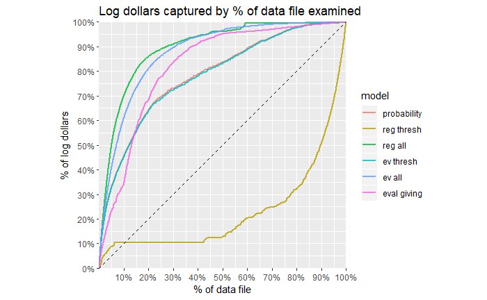

```r
duc_data %>%
  ggplot(aes(x = pct, y = logdollars, color = model)) +
  geom_line(size = 1, alpha = .8) +
  geom_abline(slope = 1, intercept = 0, linetype = 'dashed', col = 'black') +
  scale_x_continuous(breaks = seq(0, 1, by = .1)
                     , labels = seq(0, 1, by = .1) %>% scales::percent()
                     , expand = c(0, 0)) +
  scale_y_continuous(breaks = seq(0, 1, by = .1)
                     , labels = seq(0, 1, by = .1) %>% scales::percent()
                     , expand = c(0, 0)) +
  coord_equal() +
  labs(
    title = 'Log dollars captured by % of data file examined'
    , x = '% of data file'
    , y = '% of log dollars'
  )
```

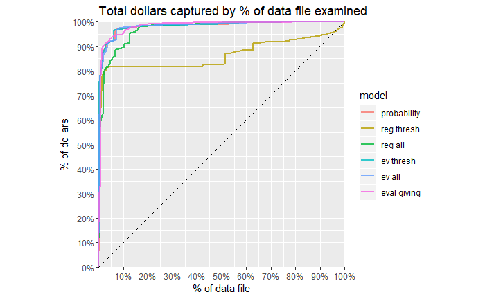

```r
duc_data %>%
  ggplot(aes(x = pct, y = dollars, color = model)) +
  geom_line(size = 1, alpha = .8) +
  geom_abline(slope = 1, intercept = 0, linetype = 'dashed', col = 'black') +
  scale_x_continuous(breaks = seq(0, 1, by = .1)
                     , labels = seq(0, 1, by = .1) %>% scales::percent()
                     , expand = c(0, 0)) +
  scale_y_continuous(breaks = seq(0, 1, by = .1)
                     , labels = seq(0, 1, by = .1) %>% scales::percent()
                     , expand = c(0, 0)) +
  coord_equal() +
  labs(
    title = 'Total dollars captured by % of data file examined'
    , x = '% of data file'
    , y = '% of dollars'
  )
```

Finally, consider the best-case scenario for the thresholded model: where giving below the $10,000 level is set to 0.

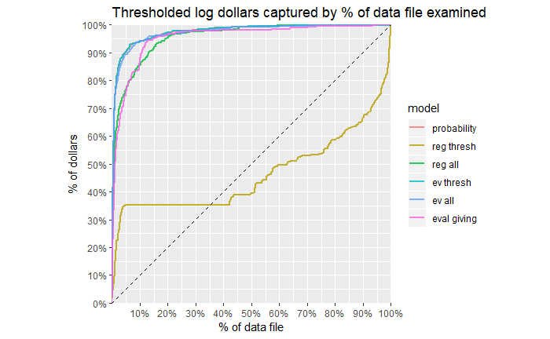

```r
thresholder <- function(x) {
  ifelse(x < log10plus1(giving.threshold), 0, x)
}
rbind(
  data.frame(model = 'probability', duc_data_gen(
    predictions$prob.mod
    , thresholder(predictions$truth)
  ))
  , data.frame(model = 'reg thresh', duc_data_gen(
    predictions$reg.mod
    , thresholder(predictions$truth)
  ))
  , data.frame(model = 'reg all', duc_data_gen(
    predictions$allreg.mod
    , thresholder(predictions$truth)
  ))
  , data.frame(model = 'ev thresh', duc_data_gen(
    predictions$ev.thresh
    , thresholder(predictions$truth)
  ))
  , data.frame(model = 'ev all', duc_data_gen(
    predictions$ev.all
    , thresholder(predictions$truth)
  ))
  , data.frame(model = 'eval giving', duc_data_gen(
    eval_giving$fitted
    , thresholder(eval_giving$rv.amt)
  ))
) %>%
  ggplot(aes(x = pct, y = logdollars, color = model)) +
  geom_line(size = 1, alpha = .8) +
  geom_abline(slope = 1, intercept = 0, linetype = 'dashed', col = 'black') +
  scale_x_continuous(breaks = seq(0, 1, by = .1)
                     , labels = seq(0, 1, by = .1) %>% scales::percent()
                     , expand = c(0, 0)) +
  scale_y_continuous(breaks = seq(0, 1, by = .1)
                     , labels = seq(0, 1, by = .1) %>% scales::percent()
                     , expand = c(0, 0)) +
  coord_equal() +
  labs(
    title = 'Thresholded log dollars captured by % of data file examined'
    , x = '% of data file'
    , y = '% of dollars'
  )
```

Thresholded EV has finally caught up to the all data EV, at the cost of disregarding lower-dollar giving.